# ML Course Project

Juan Emilio Miralles

2023-04-03

## Background

Our data for this project comprises a large number of exercise data from personal activity devices with accelerometers on the belt, forearm, arm, and dumbell of 6 participants. These exercises were performed in 5 different ways, either correctly or incorrectly. We are going to try to create a model to predict `classe`, the method the exercises were done, based on the accelerometer data.

## Data

We import the data sets, where the training set shows the true value of `classe`, and the testing set does not. We put aside the testing set for the final quiz.

## Preprocessing

Now we remove columns with massive number of NA values, which reduces our number of predictors by about 100. The following columns all have 98% NA values so they will not be very useful for building the model.

```
##  [1] "max_roll_belt"            "max_picth_belt"
##  [3] "min_roll_belt"            "min_pitch_belt"
##  [5] "amplitude_roll_belt"      "amplitude_pitch_belt"
##  [7] "var_total_accel_belt"     "avg_roll_belt"
##  [9] "stddev_roll_belt"         "var_roll_belt"
## [11] "avg_pitch_belt"           "stddev_pitch_belt"
## [13] "var_pitch_belt"           "avg_yaw_belt"
## [15] "stddev_yaw_belt"          "var_yaw_belt"
## [17] "var_accel_arm"            "avg_roll_arm"
## [19] "stddev_roll_arm"          "var_roll_arm"
## [21] "avg_pitch_arm"            "stddev_pitch_arm"
## [23] "var_pitch_arm"            "avg_yaw_arm"
## [25] "stddev_yaw_arm"           "var_yaw_arm"
## [27] "max_roll_arm"             "max_picth_arm"
## [29] "max_yaw_arm"              "min_roll_arm"
```

[output cut: 19 more lines]

Here are our remaining predictors:

```
##  [1] "X"                    "user_name"            "raw_timestamp_part_1"
##  [4] "raw_timestamp_part_2" "cvtd_timestamp"       "new_window"
##  [7] "num_window"           "roll_belt"            "pitch_belt"
## [10] "yaw_belt"             "total_accel_belt"     "gyros_belt_x"
## [13] "gyros_belt_y"         "gyros_belt_z"         "accel_belt_x"
## [16] "accel_belt_y"         "accel_belt_z"         "magnet_belt_x"
## [19] "magnet_belt_y"        "magnet_belt_z"        "roll_arm"
## [22] "pitch_arm"            "yaw_arm"              "total_accel_arm"
## [25] "gyros_arm_x"          "gyros_arm_y"          "gyros_arm_z"
## [28] "accel_arm_x"          "accel_arm_y"          "accel_arm_z"
## [31] "magnet_arm_x"         "magnet_arm_y"         "magnet_arm_z"
## [34] "roll_dumbbell"        "pitch_dumbbell"       "yaw_dumbbell"
## [37] "total_accel_dumbbell" "gyros_dumbbell_x"     "gyros_dumbbell_y"
## [40] "gyros_dumbbell_z"     "accel_dumbbell_x"     "accel_dumbbell_y"
## [43] "accel_dumbbell_z"     "magnet_dumbbell_x"    "magnet_dumbbell_y"
## [46] "magnet_dumbbell_z"    "roll_forearm"         "pitch_forearm"
## [49] "yaw_forearm"          "total_accel_forearm"  "gyros_forearm_x"
## [52] "gyros_forearm_y"      "gyros_forearm_z"      "accel_forearm_x"
## [55] "accel_forearm_y"      "accel_forearm_z"      "magnet_forearm_x"
## [58] "magnet_forearm_y"     "magnet_forearm_z"     "classe"
```

## Training models

We split the training set into training and testing subsets.

A quick look at the data we are to predict, `classe` takes on one of 5 categories for the manner of doing the exercise.

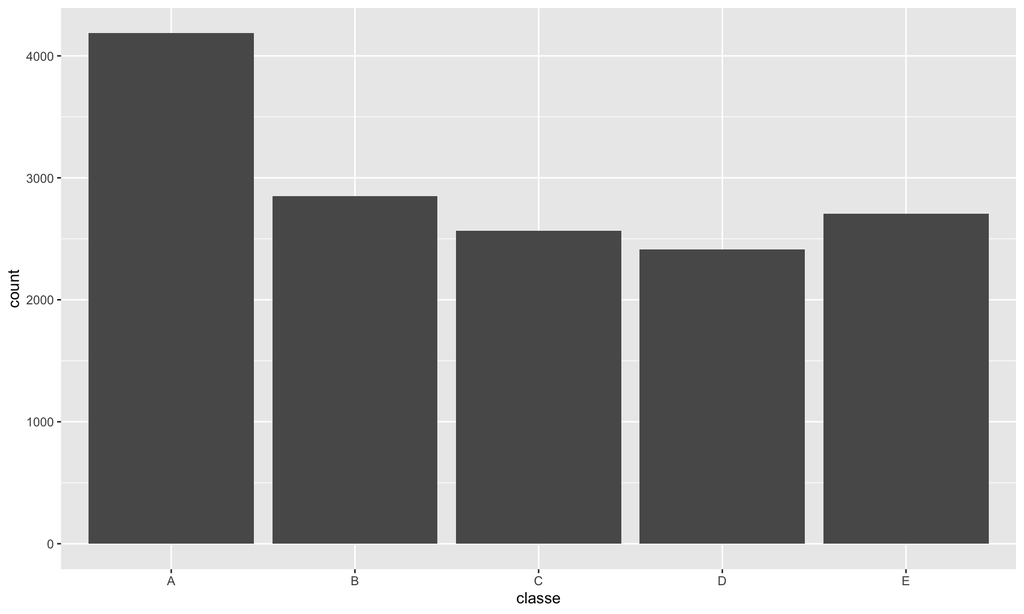

We perform random forest training with 3 subsample cross validation directly through the caret train function with trainControl.

```
## Random Forest
##
## 14718 samples
##    59 predictor
##     5 classes: 'A', 'B', 'C', 'D', 'E'
##
## Pre-processing: principal component signal extraction (81), centered
##  (81), scaled (81)
## Resampling: Cross-Validated (3 fold)
## Summary of sample sizes: 9812, 9812, 9812
## Resampling results across tuning parameters:
##
##   mtry  Accuracy   Kappa
##    2    0.9807039  0.9755889
##   41    0.9698329  0.9618397
##   81    0.9697649  0.9617550
##
## Accuracy was used to select the optimal model using the largest value.
## The final value used for the model was mtry = 2.
```

We can now check our model against the testing subset we made earlier.

```
## Confusion Matrix and Statistics
##
##           Reference
## Prediction    A    B    C    D    E
##          A 1006    0    0    0    0
##          B    0  786    0    0    0
##          C    0    0  617    0    0
##          D    0    0    0  583    0
##          E    0    0    0    0  678
##
## Overall Statistics
##
##                Accuracy : 1
##                  95% CI : (0.999, 1)
##     No Information Rate : 0.2741
##     P-Value [Acc > NIR] : < 2.2e-16
##
##                   Kappa : 1
##
##  Mcnemar's Test P-Value : NA
##
## Statistics by Class:
##
##                      Class: A Class: B Class: C Class: D Class: E
## Sensitivity            1.0000   1.0000   1.0000   1.0000   1.0000
## Specificity            1.0000   1.0000   1.0000   1.0000   1.0000
## Pos Pred Value         1.0000   1.0000   1.0000   1.0000   1.0000
## Neg Pred Value         1.0000   1.0000   1.0000   1.0000   1.0000
## Prevalence             0.2741   0.2142   0.1681   0.1589   0.1847
## Detection Rate         0.2741   0.2142   0.1681   0.1589   0.1847
## Detection Prevalence   0.2741   0.2142   0.1681   0.1589   0.1847
## Balanced Accuracy      1.0000   1.0000   1.0000   1.0000   1.0000
```

## Predictions on the quiz set

Now that we have this model, we can predict our unknown `classe` values from the quiz data set:

```
##  [1] B A A A A E D B A A B C B A E E A B B B
## Levels: A B C D E
```